# After6 Data Strategy

The purpose of this document is to provide the framework for the formal data strategy to be carried out by the After6 organization.

This is comprised of three main aspects:

1. Collection
2. Output
3. Process

It is our intention to be as explicit and comprehensive as possible for the data to be collected, and as ‘good data practice’ mandates, to be precise about how that data is to be used in way that maintains user privacy but also retains the informational-property of the company.

## Terminology

# Data Collection

- Activity Triggered Events for each User:
  - General:
    - App Launch
    - App Exit
    - App Close (?)
    - Open Settings
    - Referal Program
  - Vibes Feed:
    - Likes
    - Shares
    - Vibe Loaded
    - Auto Play
    - Manual Play
    - Enlarge Video
    - Scroll Speed
    - Profile Click from Vibe
    - Location Click from Vibe
    - Following Feed vs Global Feed
    - Searches
  - Places:
    - Vibe Click
    - Location Click
    - Profile Click
    - Launch Maps
    - Launch Phone
    - Scroll Over
    - Scroll Speed
  - Contests:
    - Submitted Contest Content (?)
    - Scroll Over
    - Scroll Speed
  - Visit Profile:
    - Already Following (?)
    - Request to Follow
    - Scroll Over
    - Scroll Speed

  …all with respect to time, location, and other standard meta data (see AWS S3 logs)
- User Profile Information:
  - User ID
  - User Name
  - Gender
  - Age
  - Location (Regional)
  - Following (or) Followers
- Content Information:
  - Content Type
  - Content Size
  - Published Date + Time

NOTE: Regarding the collection of [Raw User Input Data from a Client](http://docs.aws.amazon.com/appstream/latest/developerguide/appstream-build-app-user-data-raw.html):

> The Amazon AppStream Application and Client SDKs also provide an API to capture raw input, which you can use to handle other types of input such as accelerometer or global positioning system (GPS) data.

> When a client sends keyboard, mouse, or touch user input to your application, the `XStxServer` object fires an `XStxIRawInputSinkFcnOnRawInput` event. The data is transmitted as a raw stream of bytes. Your callback function to handle this event is responsible for interpreting the byte stream data. This requires close integration between your application and its client applications.

# Data Outputs

The potential of the data could be broken up to serve three main things:

1. **Behavior**: how can we segment our users based on their overal activity
2. **Engagement**: on a big picture scale, where can we see trends in activity
3. **Retention**: how are we increasing app downloads, and how do we make the growth sustainable

## Behavior

Cluster Users based on demographics and overal activity: active, passive, and empty sessions.

1. Demographics:
   - age
   - gender
   - location
     - regionally where are they located
     - home location
     - work location
2. Active Session:
   - how often do they post?
   - how popular is their content?
   - what type of content do they post the most? (video, images, etc)
   - do they post content relavent to any competitions or in-app promotions? (sponsored activity)
   - when do they generally post?
   - where are they when they post?
   - is there a theme in their posted content, ie bar posts, restaurant posts?
3. Passive & Empty Session:
   - how often do they ‘like’, ‘share’, or ‘view’ content?
   - how long do they spend with the app open?
   - when do they generally use the app?
   - where are they when they view the app?
   - is there a theme to their more viewed content, ie bar posts, restaurant posts?

This sort of analysis is great for the advertising end of the app. By better understanding who our users are, the better we can stream relavent sponsored content to them thereby improving effectivness of advertising and user experience.

*SAMPLE SEGMENTATION USING FAKE DATA*

| Segmentation Type | **Yuppies** | **Young at Heart** | **Just Bored** | **Social Star** |
| --- | --- | --- | --- | --- |
| % of all Users | 30% | 20% | 40% | 10% |
| Active Participation | Average | Average | Low | High |
| Passive + Empty Participation Location | Work | Work | Home | Other |
| Favorite Content | Bar | All | All | All |
| Median Age | 25 | 35 | 23 | 23 |

## Engagement

What are the users doing in the app?

This set of analysis will give us a better idea of how the app is being used so we can internally adapt the product to how it is more being utilized.

### Traffic Trends

- Posts: The posting trends throughout a day or week. Also the post type How are users using the *social* aspect of the app and how can we adapt the product with respect to the results?
- Views: The *passive* view trends; when a user is more likely to spend time browsing the feed rather than *actively* posting What do users look for when going through the feed?
- Check-Ins: Number of instances that a user checked-in or posted about a location
- Lifetime: How long do content stay relavent. How many interactions can we predict based off historical data

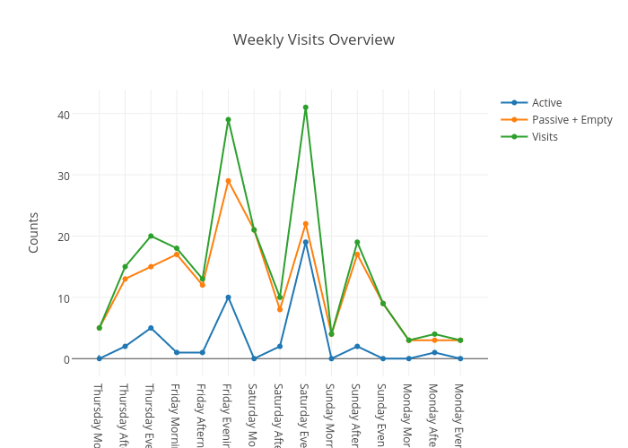

### Contest Metrics

What concrete deliverables can we give to contest sponsors?

- Content: Number of individual posts created and submitted for the contest
- Views: The aggregated views and interactions resulted from the contest content
- Summary: Subset of User Metrics with respect to contest content: who, where, when, how?

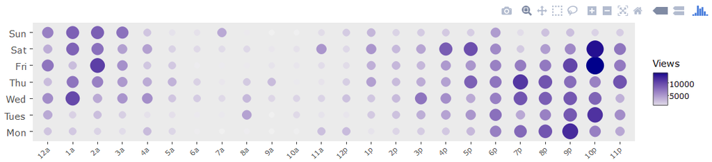

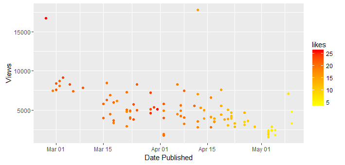

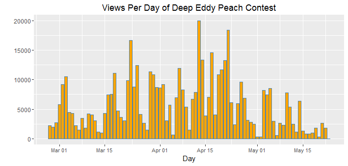

## Retention

Are users using the app?

Daily + Weekly + Monthly Traffic Overview

- Usage: Average amount of time with the app open for each session This gives us insight into how the app is being used
- Sessions: Number of *unique sessions* to the app Count the number of times the app was opened.
- Views: Number of *content hits* Count the instances that a content was viewed in either auto or manual play
- Audience Size: Number of *unique viewers* to the app Filter *Sessions* with unique *user names*
- New Users: the number of new accounts created

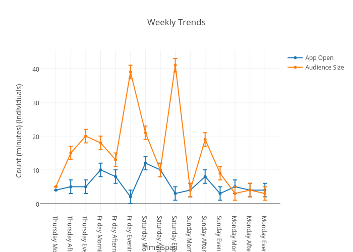

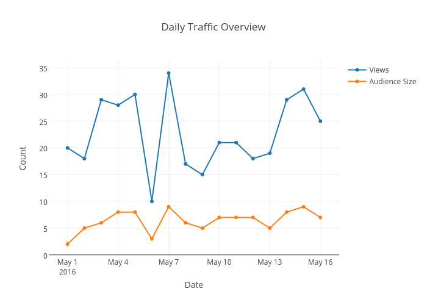

# Data Process

How will data be collected and stored to later be accessed for analysis?

## Data Lifecycle

The data process needs to be flexible and sustainable to allow for longterm policy in data’s lifecycle: collection, storage, and use.

AWS Mobile Services has an Analyitcs service that displays basic content but allows for automatic data transfer to the Redshift service through the Cloud Formation Service. An in-house Amazon EC2 Python Application Instance checks for new data in the relavent S3 Bucket and then pushes the new data to the Redshift data warehouse.

Data in the Redshift warehouse can be accessed via 3rd party applications to perform basic queries and exports.

## Data Storage

Leveraging AWS Redshift, we can have one location for all data, and then build/update tables that are relavent to the Outputted Content detailed above. Tables are recommended to be created and stored similar to the outline provided in the Data Collection Section.